# EP1162 volume estimates

Hardy Griesbauer

26/03/2020

## Volume estimates for EP1162

We will estimate volume estimates using the following approach:

1. Estimate heights for trees without height measurements, using DBH:height models developed earlier using EP1162 data
2. Estimate volume using equations from Nigh (2016) for specific species and BGC units

Source for Nigh (2016): https://www.for.gov.bc.ca/hfd/pubs/docs/TR/TR106.htm

**NB Plots 16-19 omitted from this analysis**

#### Estimate Heights

From earlier analyses, we calculated intercept and slope coefficients to estimate spruce and subalpine fir heights using DBH. The formula is: Height = b1*ln(DBH)+b0

Coefficients were developed separately for each measurement period. Analysis showed that the regression did not vary significantly between spruce and subalpine fir, therefore, we developed the coefficients by pooling data for both species within a measurement year.

```r
 hm<-
  heightModels %>%
  dplyr::rename(b0=intercept,b1=slope) %>%   # rename columns
  mutate(year=factor(year))

# Print to screen
hm
```

```
## # A tibble: 5 x 5
##   year     b0    b1    p.value r.squared
##   <fct> <dbl> <dbl>      <dbl>     <dbl>
## 1 1992  -21.1  12.6  2.67e- 46     0.845
## 2 1994  -20.5  12.4  1.07e- 60     0.905
## 3 1997  -20.1  12.2  4.07e- 58     0.899
## 4 2009  -19.0  11.7 NA            NA
## 5 2019  -18.1  11.3  3.31e-210     0.839
```

Table shows coefficients for height models for each measurement period. P value and R<sup>2</sup> values are from linear regression.

Note missing p values and r square for 2009 year - these coefficients were estimated from 1997 and 2019 data.

#### Nigh equations

Hardcode Nigh’s 2016 total (Table 9) and merchantable (Table 11) volume equations for species and SBS BGC Zone into a table:

```r
volCoef<-

  ## TOTAL VOLUME
  #  Subalpine fir
  data.frame(Species="Bl",VolType="total",b0=-9.79,b1=1.813,b2=1.033) %>%

  # Douglas-fir
  add_row(Species="Fd",VolType="total",b0=-10.19,b1=1.73,b2=1.206) %>%

  # Add spruce
  add_row(Species="Sx",VolType="total",b0=-10.024,b1= 1.801,b2= 1.107) %>%

  ## MERCHANTABLE VOLUME
  # Subalpine fir
  add_row(Species="Bl",VolType="merch",b0=-9.980,b1= 1.792,b2= 1.102) %>%

  # Douglas-fir
  add_row(Species="Fd",VolType="merch",b0=-10.503,b1= 1.724,b2= 1.296) %>%

  # Spruce
  add_row(Species="Sx",VolType="merch",b0=-10.280,b1= 1.769,b2= 1.206 ) %>%

  mutate(BGC.Zone="SBS") %>%

  # convert species to factor
  mutate(Species=factor(Species)) %>%
  dplyr::select(Species,BGC.Zone,everything())

# print to screen
volCoef
```

```
##   Species BGC.Zone VolType      b0    b1    b2
## 1      Bl      SBS   total  -9.790 1.813 1.033
## 2      Fd      SBS   total -10.190 1.730 1.206
## 3      Sx      SBS   total -10.024 1.801 1.107
## 4      Bl      SBS   merch  -9.980 1.792 1.102
## 5      Fd      SBS   merch -10.503 1.724 1.296
## 6      Sx      SBS   merch -10.280 1.769 1.206
```

This table shows the coefficients used in the volume equations.

Equation: vol = e<sup>b<sub>0</sub></sup> x dbh<sup>b<sub>1</sub></sup> x height<sup>b<sub>2</sub></sup>

#### Estimate heights and volumes in dataset

We can now apply the coefficients above to estimate heights for trees that do not have height measurements:

```r
dat<- # we will update dat dataset
  dat %>%

  # Height estimates
  left_join(hm[,1:3],by=c("Year"="year")) %>% # add coefficients to table
  mutate(heightVol=coalesce(Height,b0+b1*log(DBH))) %>%   # populate new height column height estimates
  dplyr::select(-b0,-b1) %>%  # remove coefficients

  # Total volume estimates
  left_join(filter(volCoef,VolType=="total"),by=c("Species")) %>% #add total volume coefficients to table
  mutate(totalVol=exp(1)^b0*DBH^b1*heightVol^b2) %>% # estimate volume
  dplyr::select(Plot:heightVol,totalVol) %>% # remove coefficients and other extraneous columns

  # Merchantable volume estimates
    left_join(filter(volCoef,VolType=="merch"),by=c("Species")) %>% #add merch volume coefficients to table
  mutate(merchVol=exp(1)^b0*DBH^b1*heightVol^b2) %>% # estimate volume
  dplyr::select(Plot:totalVol,merchVol)

# save output
save(dat,file=here::here("data","ep1162_Data_Volumes.RData"))

# write to .csv
write.csv(dat,file=here::here("data","ep1162_Data_Volumes.csv"))
```

**As per Mike’s suggestion, I double checked that the estimates are reasonable by comparing estimates to the volume formula for a cone (Height*BA/3) - estimates appear correct**

## Preliminary volume analysis

Produce some preliminar graphs based on total volume estimates:

### Histogram of total volume estimates

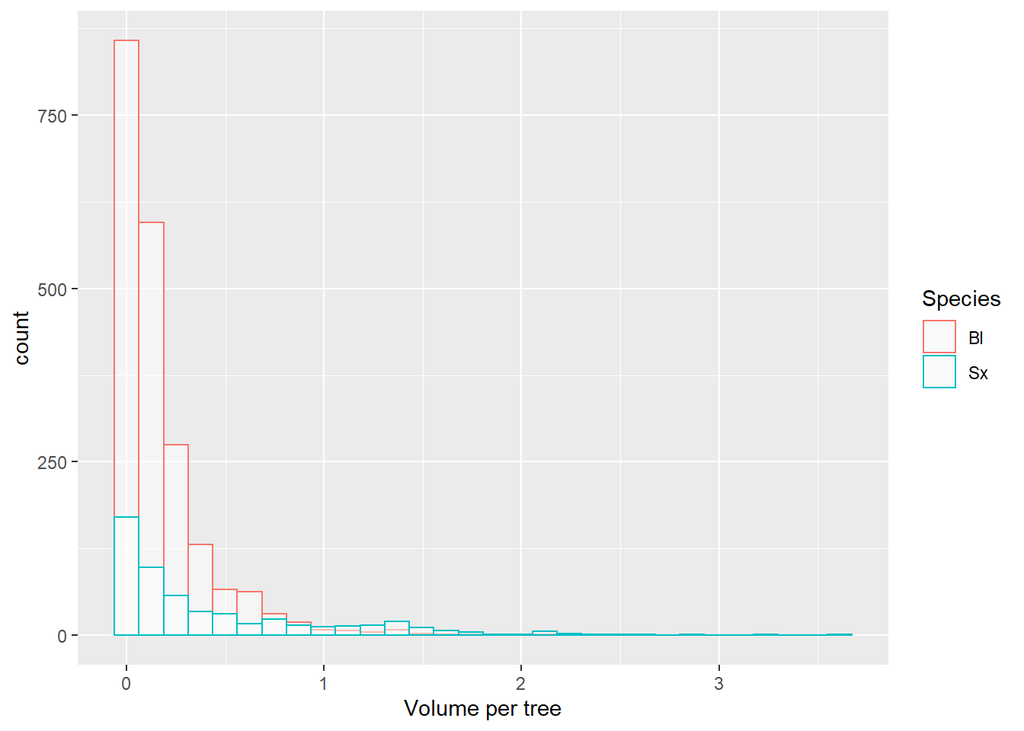

```r
dat %>%
  left_join(plotDat,by="Plot") %>% # join with plot data
  filter(Status=="Live") %>% # filter for live trees only
  filter(Species %in% c("Bl","Sx")) %>% # only for Sx and Bl

  ggplot()+
  aes(x=totalVol,color=Species)+
  geom_histogram(fill="white", alpha=0.5, position="identity")+
  xlab("Volume per tree")
```

Data are right skewed, as expected in an uneven-aged stand.

### Mean volume per plot per year and treatment

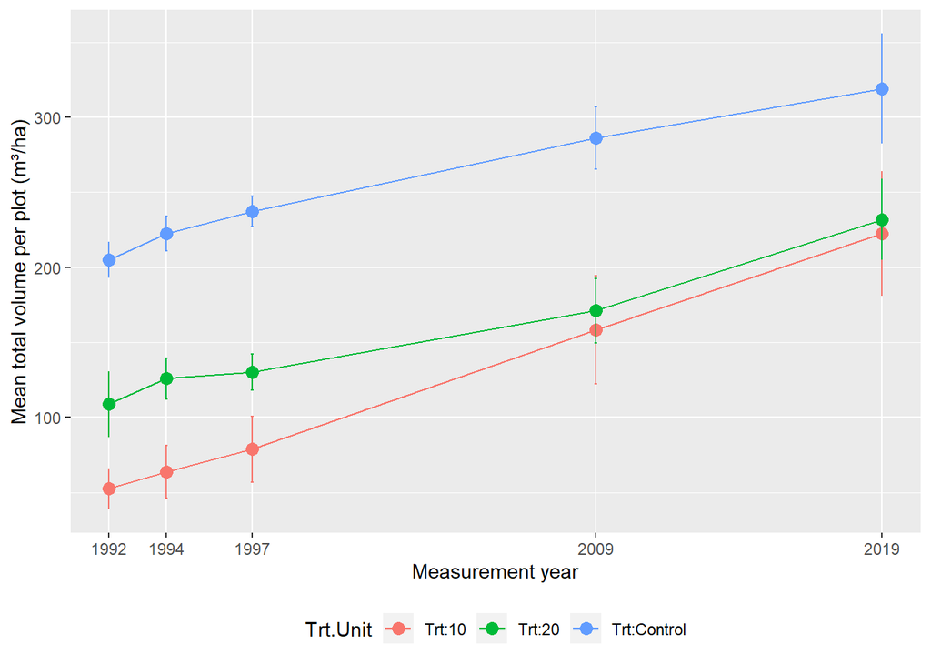

```r
dat %>%
  left_join(plotDat,by="Plot") %>% # join with plot data
  filter(Status=="Live") %>% # filter for live trees only

  # plot multiplier
  mutate(merchVol=merchVol*20) %>%
  mutate(totalVol=totalVol*20) %>%

  # Summarise mean plot volume at the treatment unit and year levels
  group_by(BA.Target,Plot,Year) %>%
  summarise(merchVol=sum(merchVol,na.rm=TRUE),
            totalVol=sum(totalVol,na.rm=TRUE)) %>%
  ungroup() %>%
    group_by(BA.Target,Year) %>%
    summarise(merch.Vol=mean(merchVol,na.rm=TRUE),
            total.Vol=mean(totalVol,na.rm=TRUE),
            total.se=sd(totalVol)/sqrt(length(totalVol)),
            merch.se=sd(merchVol)/sqrt(length(merchVol)))  %>%

    # Add labeller column
  mutate(Trt.Unit=factor(paste("Trt:",BA.Target,sep=""))) %>%

  # Need to transform year format
    mutate(Year=as.numeric(as.character(Year))) %>%

ggplot()+
  aes(x=Year,y=total.Vol,color=Trt.Unit,group=Trt.Unit)+
  geom_point(size=3)+
  geom_line()+
  geom_errorbar(aes(ymin=total.Vol-total.se,ymax=total.Vol+total.se),width=0.1)+
  xlab("Measurement year")+
  ylab("Mean total volume per plot (m³/ha)")+
  theme(legend.position = "bottom")+
    scale_x_continuous(limits=c(1992,2019),breaks=c(1992,1994,1997,2009,2019),
                     minor_breaks = c(1992,1994,1997,2009,2019),
                     name="Measurement year")
```

### Volume for all plots

Plot out volume by year for all plots:

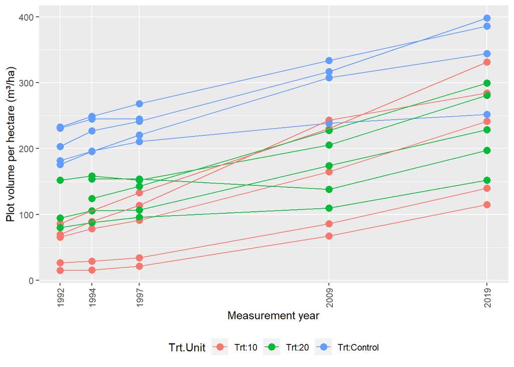

```r
dat %>%
   left_join(plotDat,by="Plot") %>% # join with plot data
  filter(Status=="Live") %>%
  mutate(Plot=paste("Plot:",Plot,sep="")) %>%
  mutate(Year=as.numeric(as.character(Year))) %>%
  mutate(Trt.Unit=factor(paste("Trt:",BA.Target,sep=""))) %>%
  group_by(Trt.Unit,Plot,Year) %>%
  summarise(vol=sum(totalVol)*20) %>% # multiply by 20 for volume/ha


  # Plotting
  ggplot()+
  aes(x=Year,y=vol,color=Trt.Unit,group=Plot)+
  geom_point(size=3)+
  geom_line()+
  ylab("Plot volume per hectare (m³/ha)")+
  scale_x_continuous(limits=c(1992,2019),breaks=c(1992,1994,1997,2009,2019),
                     minor_breaks = c(1992,1994,1997,2009,2019),
                     name="Measurement year")+ # stretch out x-axis
  theme(axis.text.x = element_text(angle = 90, hjust = 1,vjust=0.5),
        legend.position = "bottom")
```

### Periodic volume increment

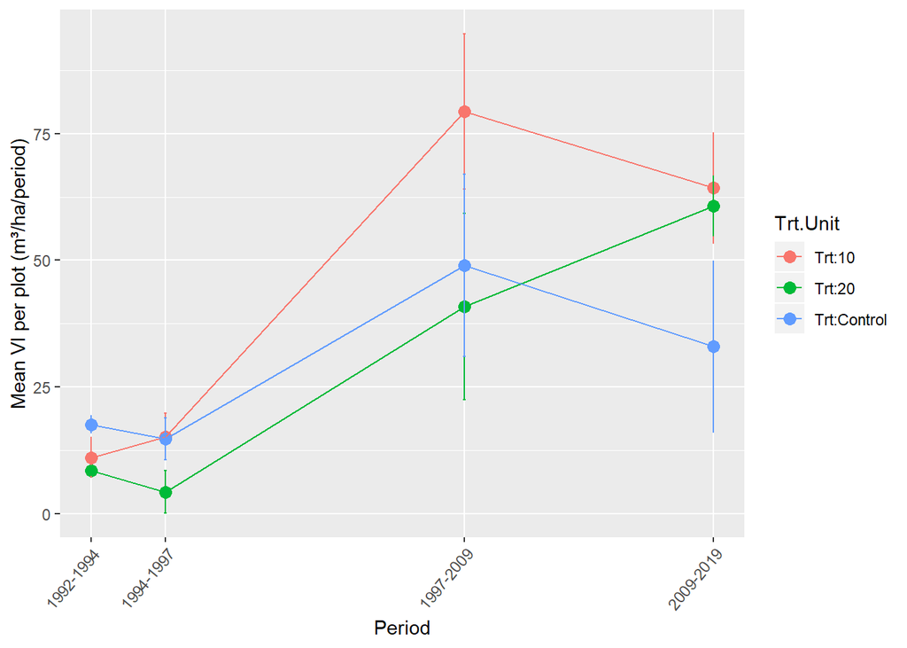

```r
dat %>%
  left_join(plotDat,by="Plot") %>% # join with plot data
   filter(Status=="Live") %>% # filter for live trees only
  dplyr::select(BA.Target,Plot,TreeID,Species,Year,totalVol) %>%
  group_by(BA.Target,Plot,Year) %>%
  summarise(vol.Sum=sum(totalVol,na.rm=T)*20) %>% # plot multiplier
  pivot_wider(names_from=Year,values_from=vol.Sum) %>%
  mutate(`1992-1994`=`1994`-`1992`) %>%
  mutate(`1994-1997`=`1997`-`1994`) %>%
  mutate(`1997-2009`=`2009`-`1997`) %>%
  mutate(`2009-2019`=`2019`-`2009`) %>%

  # pivot back
  dplyr::select(BA.Target,Plot,`1992-1994`:`2009-2019`) %>%
  pivot_longer(cols=`1992-1994`:`2009-2019`,names_to="Period",values_to="PVI") %>%
  mutate(Period=factor(Period)) %>%

  # summarise PBAI by BA.Target
  group_by(BA.Target,Period) %>%
  summarise(PVI.mean=mean(PVI,na.rm=T),
            PVI.se=sd(PVI,na.rm=T)/sqrt(length(PVI))) %>%

    # Add labeller column
  mutate(Trt.Unit=factor(paste("Trt:",BA.Target,sep=""))) %>%

  # Add new column for plotting
  mutate(Meas.Year=str_split_fixed(Period,"-",n=2)[,2]) %>% # extract measurement year
  mutate(Meas.Year=as.numeric(Meas.Year)) %>%

  # Plotting
  ggplot()+
  aes(x=Meas.Year,y=PVI.mean,fill=Trt.Unit,color=Trt.Unit,group=Trt.Unit)+
  geom_point(size=3)+
  geom_line()+
  geom_errorbar(aes(ymin=PVI.mean-PVI.se,ymax=PVI.mean+PVI.se),width=0.1)+
  xlab("Period")+
  ylab("Mean VI per plot (m³/ha/period)")+
  scale_x_continuous(limits=c(1994,2019),breaks=c(1994,1997,2009,2019),
                     labels = c("1992-1994","1994-1997","1997-2009","2009-2019"),
                     name="Period",
                     minor_breaks = c(1994,1997,2009,2019))+ # stretch out x-axis
  theme(axis.text.x = element_text(angle = 50, hjust = 1))
```